# Changes in life values for females of different age groups

#### The whole dataset: HappyDB is a corpus of 100,000 crowd-sourced happy moments via Amazon’s Mechanical Turk. You can read more about it on https://arxiv.org/abs/1801.07746. But I only use a subset of this dataset to conduct data analysis in this report.

First, I processed the raw textual data ‘cleaned_hm.csv’ saved in $ data $ file by cleaning data, removing stopwords and creating a tidy version of texts which is saved in $ output $ file.

Then, I combined the processed text with demographic information ‘demographic.csv’ saved in $ data $ file to generate the dataset for this report.

## Question 1: What make Females in their 10s, 20s, 30s, and 60s happy?

One of the things I do every New Year is to set goals for the new year. Establishing life values is very important to me as I try to live the new year with a new mindset that will help me become a better, happier me. From that perspective, if I could know what life values in general make each age groups happy in advance, I would be able to focus more on those things. Thus, I began this project by looking into which moments compose each age groups’ happy moments. I divided the age groups into females in their 10s, 20s, 30s, and 60s.

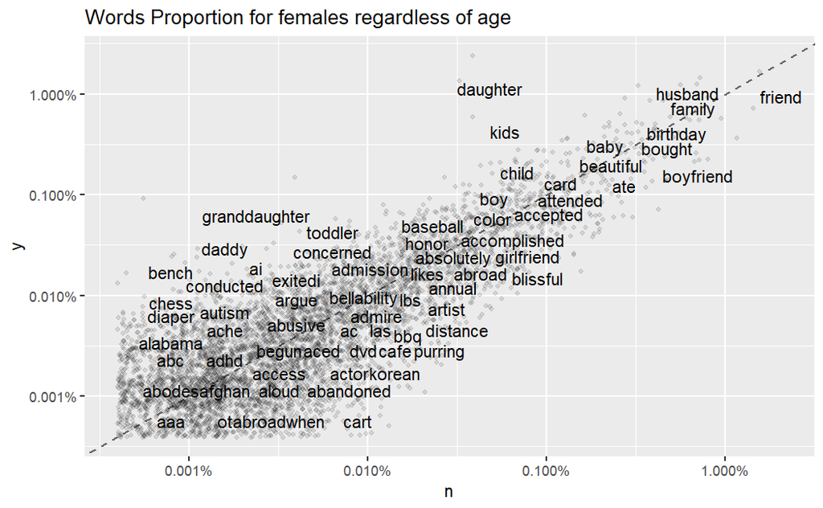

According to the plot above, regardless of age, females think of “friend”, “husband”, “family”, and “birthday” in their happy moments.

This seemed very general, so I broke it down to 4 different age groups and saw what words/values pop up frequently respectively.

#### Word Cloud

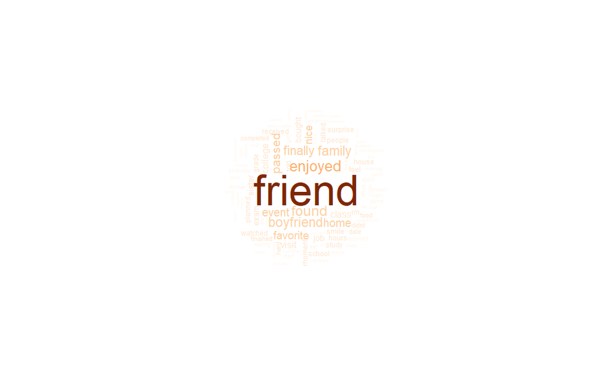

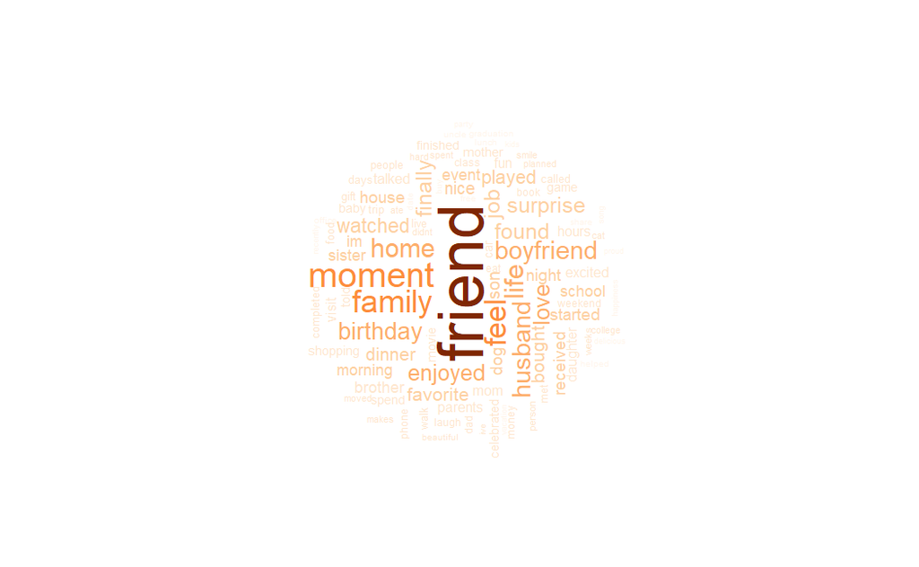

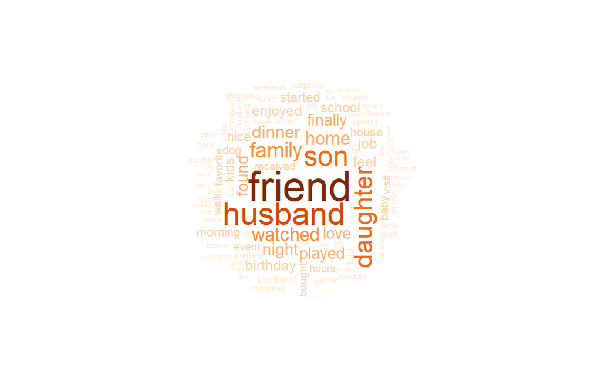

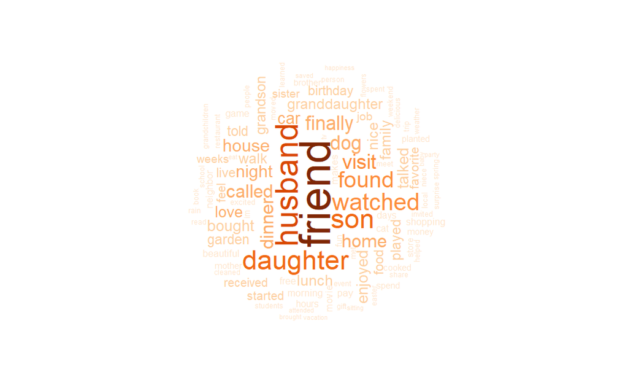

#### Bar Charts

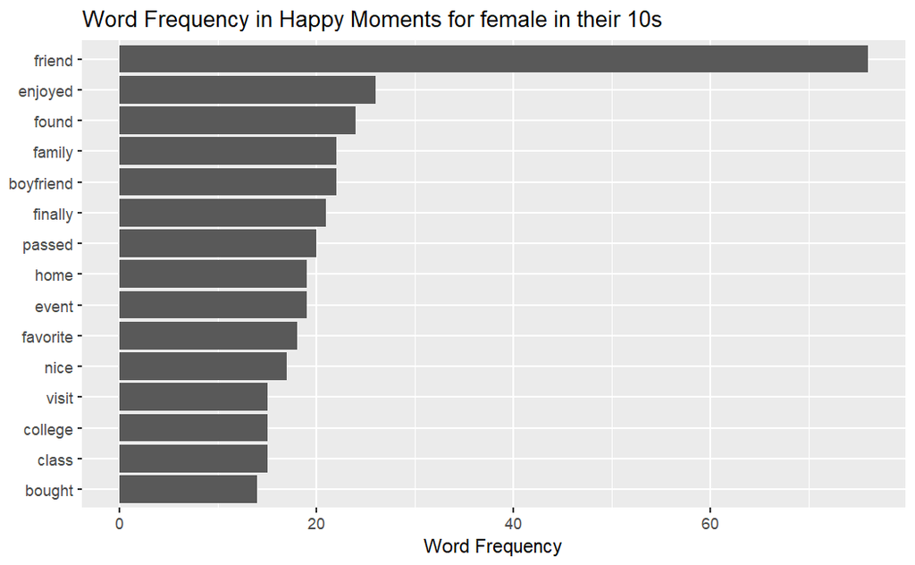

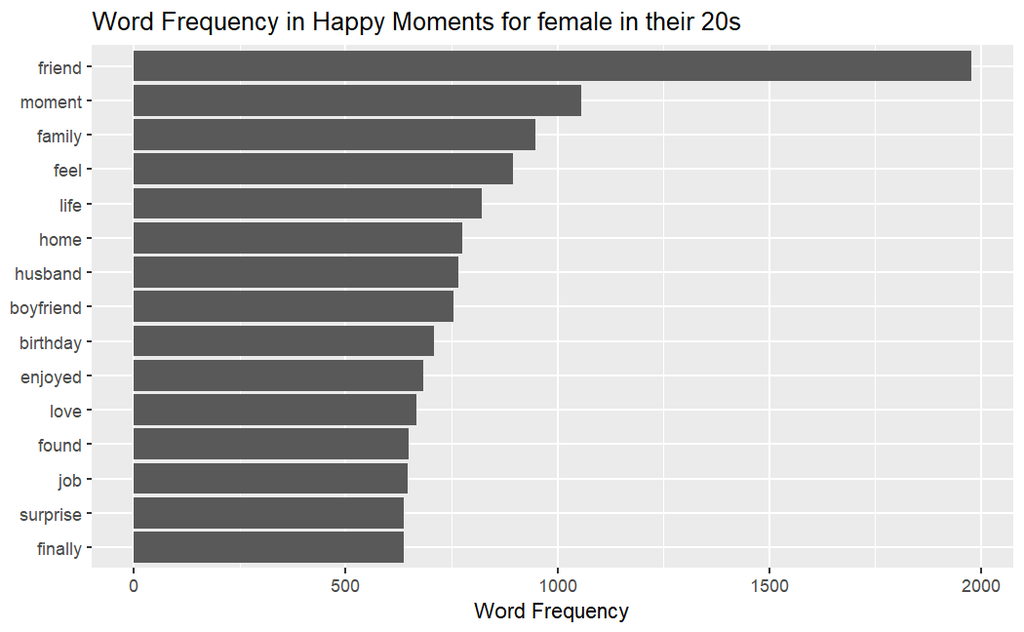

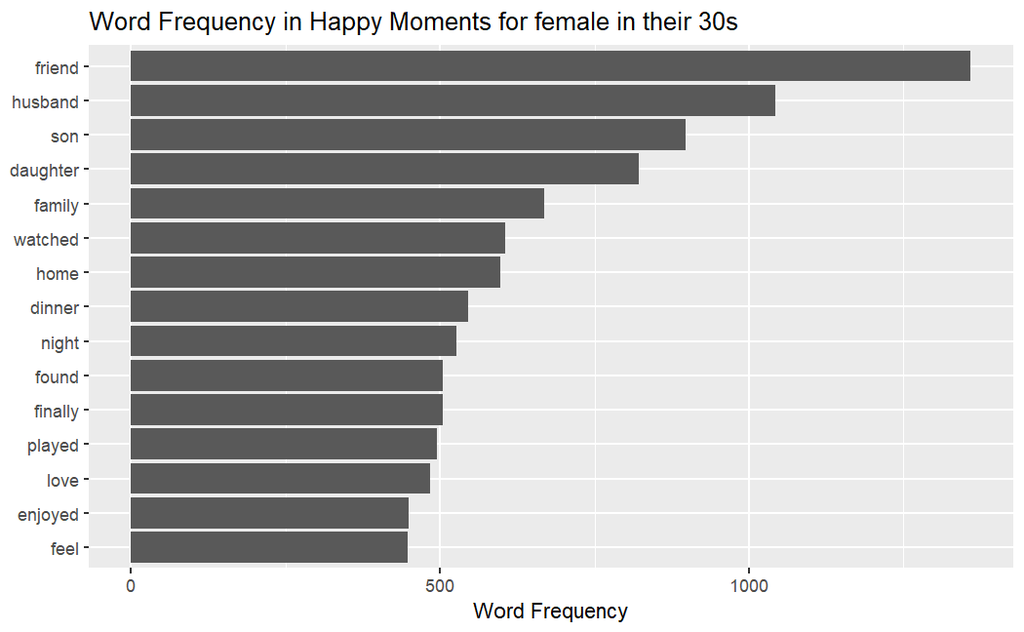

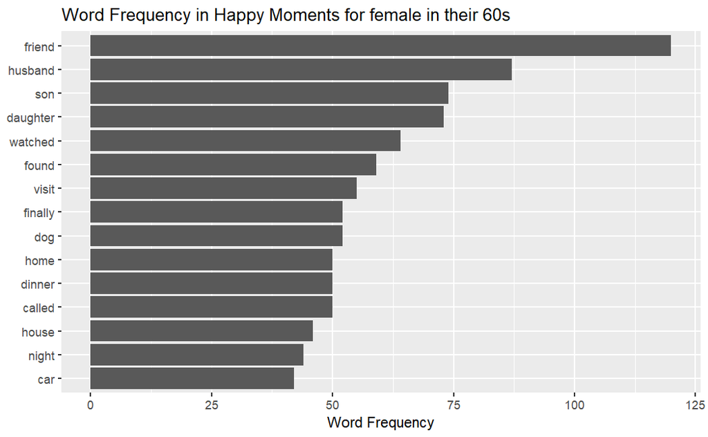

## Question 2: Other than friends and families, which factors make females happy?

Since friends and families were obvious factors that consisted the female’s happiness, I excluded those words and focused on other words that were frequently mentioned.

#### < 10s >

```
[1] 82
```

Of the 82 happy moments that aren’t related to ‘friends’ or ‘families’ for the teenage females, the frequency of the rest words are as follows:

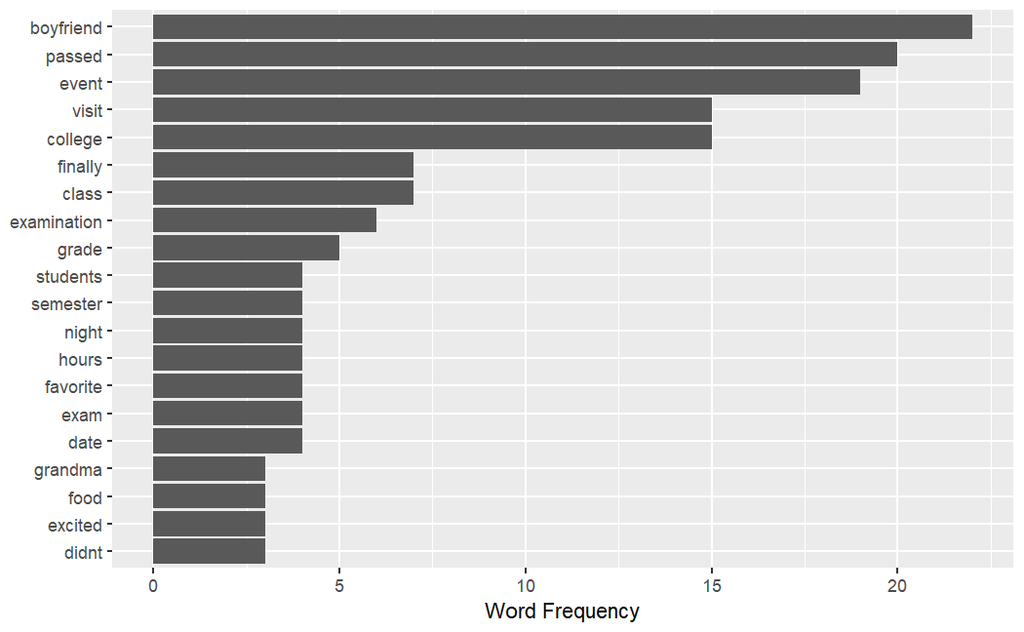

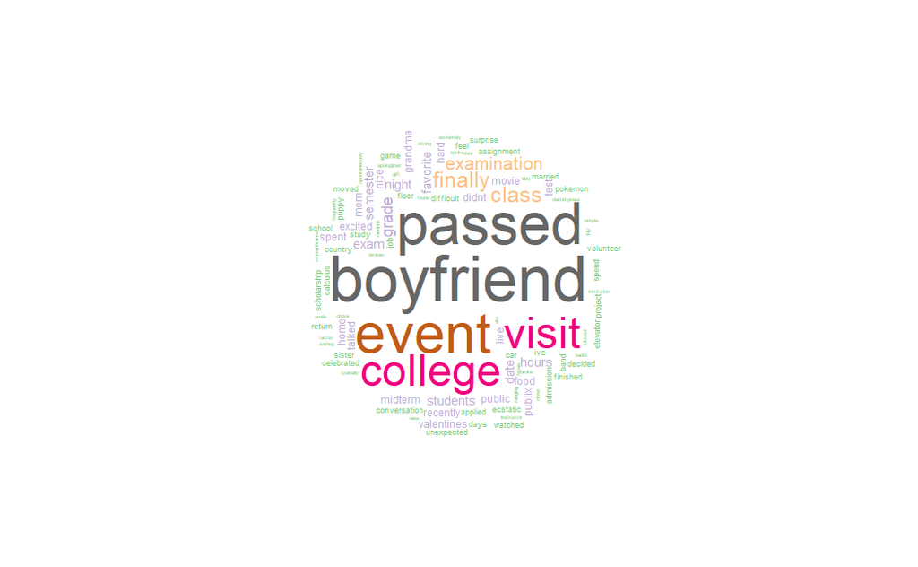

#### < 20s >

For the females in their 20s, the frequency of happy moments that aren’t related to ‘friends’ or ‘families’ are as follows:

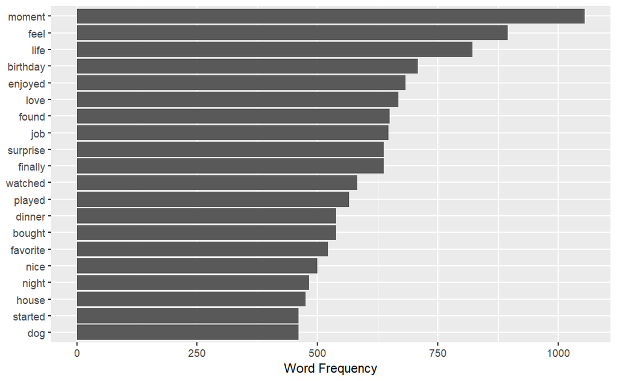

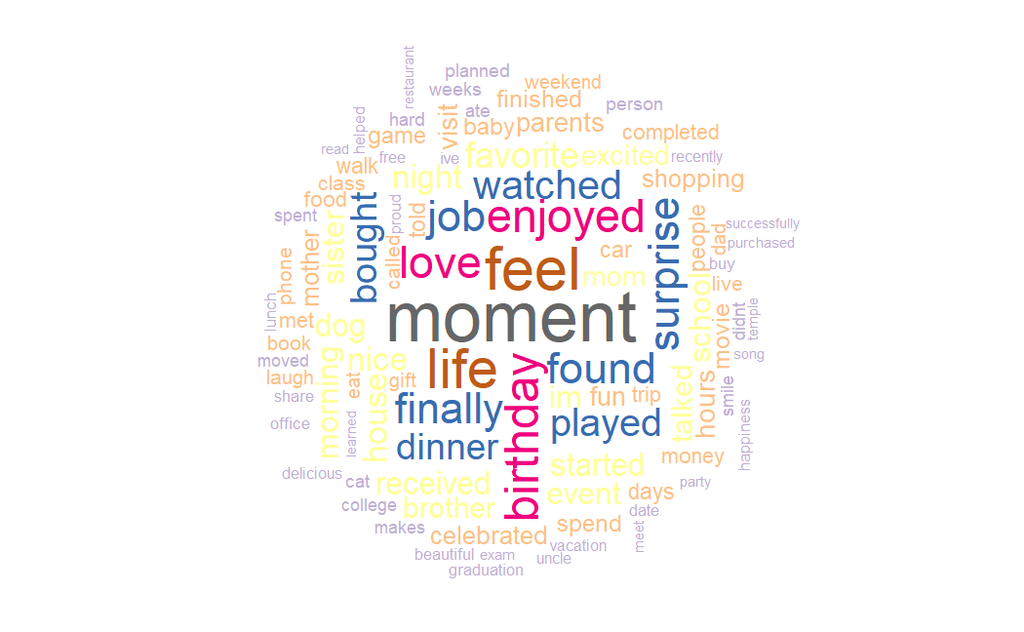

#### < 30s >

For the females in their 30s, the frequency of happy moments that aren’t related to ‘friends’ or ‘families’ are as follows:

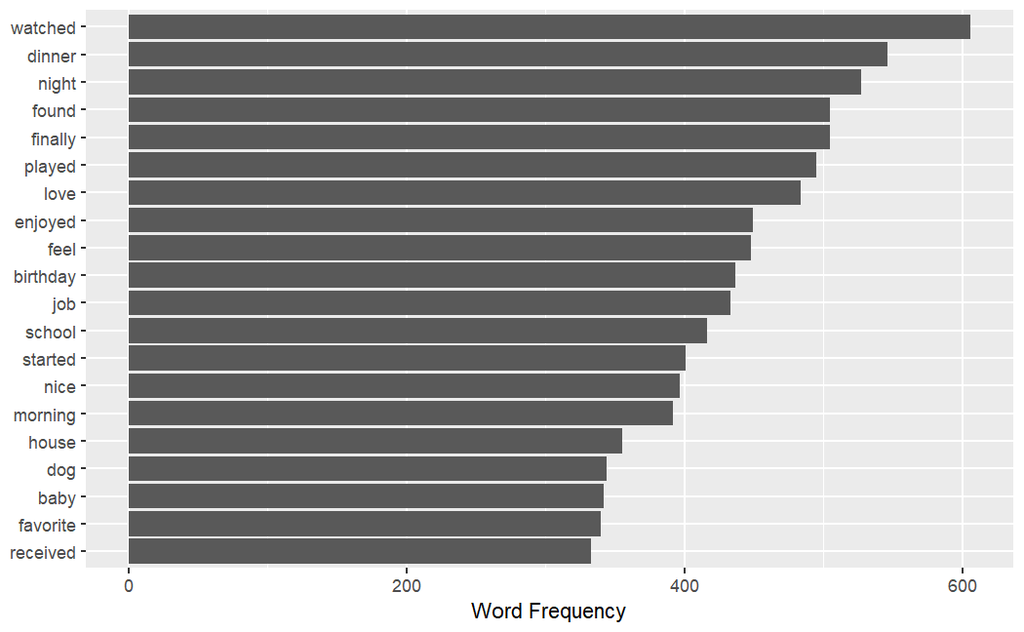

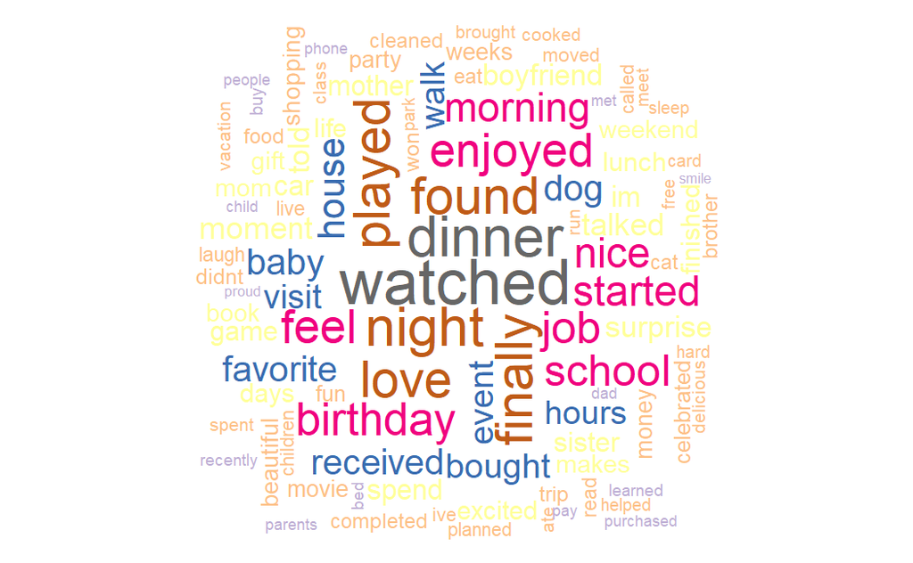

#### < 60s >

For the females in their 60s, the frequency of happy moments that aren’t related to ‘friends’ or ‘families’ are as follows:

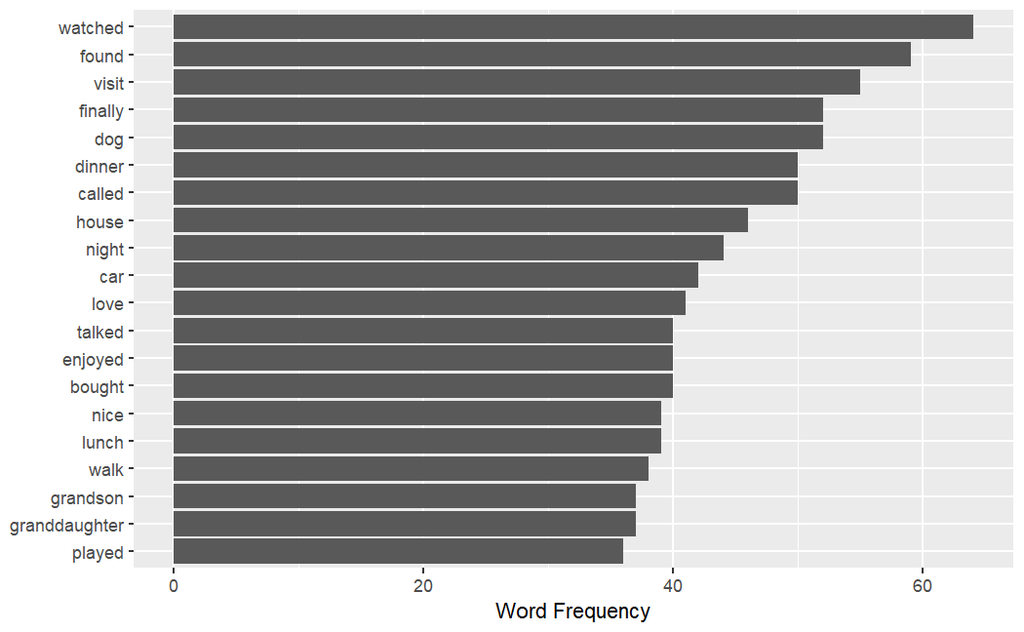

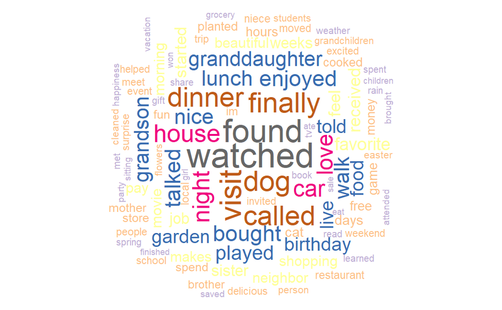

### 10s - boyfriend, passed, event, visit, college

### 20s - moment, feel, life, birthday, love, job

### 30s - watched, dinner, night, played, love

### 60s - watched, found, visit, dog, dinner, car

Below are some examples of the happy moments of each age groups.

| original_hm |
| --- |
| Passing my midterm exams |
| When i passed my midterm exams |
| I was able to pass a test that I didn't study for. |
| Passing an assignment for a scholarship scheme for the university mentioned in 1. |
| i passed publix examination first class so i am very happy |
| NA |

| original_hm |
| --- |
| I finally decorated my son's room for his birthday. |
| My best friend birthday |
| My friends birthday was today. We went to applebee's. |
| my brother son birthday |
| I got to eat cake on my son's birthday after abstaining from sugar for a month. It was delightfully exciting. |
| THE BIRTHDAY PARTY OF MY NIECE MADE ME HAPPY.TWO WEEKS BACK WE CELEBRATE HER FIRST BIRTHDAY AT OUR HOUSE.THE WHOLE DAY WE ENJOYED AT THE CORE.NOTHING CAN EQUAL TO HER SMILE. |

| original_hm |
| --- |
| My husband made me my favorite food for dinner. |
| My mom took us to dinner and I ate a shrimp chimichanga |
| My mother and law she cooked the kids dinner. She talked to me when I fought with my husband late yesterday evening. I was worried I was going to go to hell for disowning my insane parents. They are b… |
| Being able to see my siblings and mom smile and laugh together at the dinner table last night. |
| Having a nice, relaxed dinner with my boyfriend last night made me happy. |
| I had really good tacos for dinner. |

| original_hm |
| --- |
| I went for a walk with my husband and my dog. the sun was shining and the birds singing, a perfect spring day. |
| Literally, stopping to smell a beautiful rose while walking my dogs. |
| I went at the park with my dog |
| Taking my morning walk with my dog this morning, I was SO happy that the cold, cold wind had finally died down, and although the temperature was still chilly, it felt so much warmer without the wind. |
| I was running low on my dog's insulin especially when a weekend is upon me. While I probably have enough, I always stress out that I will not make it until the following Monday when the vet re-opens. … |
| I am happy that my dog is finally getting over his fear of dogs and some people. |

## Conclusions

1. ‘Friends’ and ‘Families’ were always mentioned as a top value of all different age groups.
2. For females in 10s and 20s, it could be infered that they had other external factors such as ‘college’, ‘boyfriend’, ‘life’, or ‘job’ to make them happy.
3. For females in 30s and 60s, it could be infered that internal factors, or the action of doing something with people around you, inferrably friends or families, were what made them happy.